# Closeness ~ Close Out-Degree * Personal Disclosure

Ovidia Stanoi

2025-02-26

### Prepare data for regression analyses.

Remove all data from the global environment.

```r
remove(list=ls())
```

Load libraries.

```r
library("tidyverse")
library("rstanarm")
library("sjPlot")
library("brms")
library("bmlm")
```

Specify your directory path below.

```r
path <- ""
```

Open dataset.

```r
covid_ema <- read.csv(sprintf("%s/Data/all_data_merged_clean.csv", path))
```

See the distribution of the outcome variable: closeness at the end of the interaction.

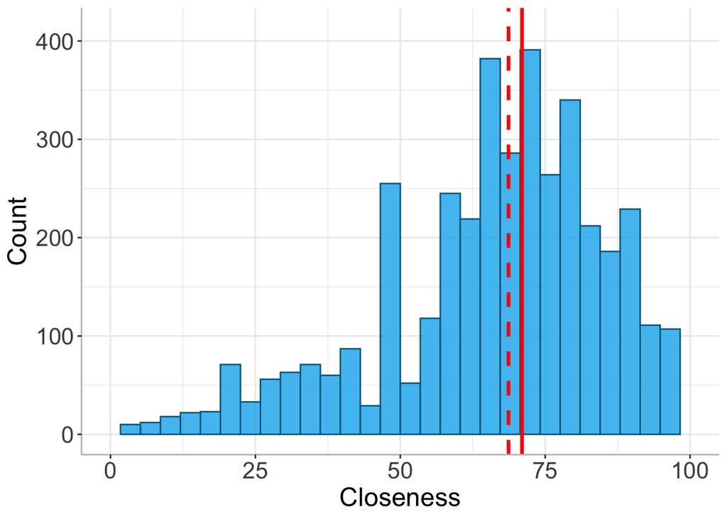

```r
ggplot(covid_ema, aes(SalInt_Close)) +
  geom_histogram(fill = "deepskyblue2", color = "deepskyblue4", alpha = .8) +
  labs(x = "Closeness",
       y = "Count") +
  geom_vline(xintercept = median(covid_ema$SalInt_Close, na.rm = T),
             color = "red", linewidth = 1.2) +
  geom_vline(xintercept = mean(covid_ema$SalInt_Close, na.rm = T),
             color = "red", linewidth = 1.2, linetype = "dashed") +
  lims(x = c(0,100)) +
  theme_bw() +
  theme(axis.text=element_text(size=16),
        plot.title = element_text(size=18, hjust = .5),
        axis.title=element_text(size=18),
        axis.line = element_line(colour = "gray"),
        panel.border = element_blank())
```

Center the continuous predictors that represent between-individual differences around the sample mean; center binary variables around zero.

```r
# Extract for each participant their close out-degree, demographic information, and COVID-19 information
df <- covid_ema %>%
  group_by(pID) %>%
  dplyr::summarise(baseline_closest_deg_out_norm = unique(baseline_closest_deg_out_norm),
                   baseline_income_num = unique(baseline_income_num),
                   baseline_educ_parents_years = unique(baseline_educ_parents_years),
                   baseline_college_year = unique(baseline_college_year),
                   baseline_gender_numeric = unique(baseline_gender_numeric),
                   covid_housing_tension = unique(covid_housing_tension),
                   covid_phys_dist = unique(covid_phys_dist_avg))

# Mean center variables
df$baseline_closest_deg_out_norm_c <- df$baseline_closest_deg_out_norm - mean(df$baseline_closest_deg_out_norm, na.rm = T)
df$baseline_income_num_c <- df$baseline_income_num - mean(df$baseline_income_num, na.rm = T)
df$baseline_educ_parents_years_c <- df$baseline_educ_parents_years - mean(df$baseline_educ_parents_years, na.rm = T)
df$baseline_college_year_c <- df$baseline_college_year - mean(df$baseline_college_year, na.rm = T)
df$baseline_gender_numeric_c <- df$baseline_gender_numeric - .5
df$covid_housing_tension_c <- df$covid_housing_tension - mean(df$covid_housing_tension, na.rm = T)
df$covid_phys_dist_c  <- df$covid_phys_dist - mean(df$covid_phys_dist, na.rm = T)

# Add centered variables to the EMA dataset
covid_ema <- merge(covid_ema, df)
```

Separate the predictor(s) that vary both between- and within-individual in their within and between components.

```r
covid_ema <- isolate(d = covid_ema, by = "pID",
                     value = c("SalInt_Disc_Self", "SalInt_Disc_Partner",
                               "SalInt_Medium_Online", "SalInt_Disc_Tension",
                               "SalInt_Partner_Close"),
                     which = "both")
```

### Run multilevel regression models

##### Model 1: Predictor Variable = Self-Disclosure

Run regression analysis 1: closeness ~ close out-degree * self-disclosure (within component).

```r
options(mc.cores = parallel::detectCores())
fit1 <- stan_glmer(SalInt_Close ~ SalInt_Disc_Self_cw * baseline_closest_deg_out_norm_c +
                     SalInt_Medium_Online_cw + SalInt_Disc_Tension_cw  +
                     SalInt_Partner_Close_cw + baseline_income_num_c +
                     baseline_educ_parents_years_c + baseline_college_year_c +
                     baseline_gender_numeric_c + covid_housing_tension_c +
                     covid_phys_dist_c + (SalInt_Disc_Self_cw | groupID:pID),
                    data = covid_ema, seed = 123)
save(fit1, file = sprintf("%s/Models/3.Closeness_Out-Degree_Self-Disclose.RData", path))
```

##### Model 2: Predictor Variable = Partner-Disclosure

```r
options(mc.cores = parallel::detectCores())
fit2 <- stan_glmer(SalInt_Close ~ SalInt_Disc_Partner_cw * baseline_closest_deg_out_norm_c +
                     SalInt_Medium_Online_cw + SalInt_Disc_Tension_cw  +
                     SalInt_Partner_Close_cw + baseline_income_num_c +
                     baseline_educ_parents_years_c + baseline_college_year_c +
                     baseline_gender_numeric_c + covid_housing_tension_c +
                     covid_phys_dist_c + (SalInt_Disc_Partner_cw | groupID:pID),
                    data = covid_ema, seed = 123)
save(fit1, file = sprintf("%s/Models/3.Closeness_Out-Degree_Partner-Disclose.RData", path))
```

### Summarize results

Create a table that presents the parameter estimates from the two models together.

```r
tab_model(fit1, fit2, show.se = TRUE,
          show.r2 = TRUE,
          dv.labels = c("Closeness",
                        "Closeness"),
          pred.labels = c("(Intercept)",
                          "Self-Sharing (WI)",
                          "Close Out-Degree Prior to COVID19",
                          "Online Conversation (WI)",
                          "Tension (WI)",
                          "Close Partner (WI)",
                          "HH Income",
                          "Parents' Education",
                          "Year in College",
                          "Female",
                          "HH Tension",
                          "Physical Distance",
                          "Out-Degree * Self-Sharing (WI) Interaction",
                          "Partner-Sharing (WI)",
                          "Out-Degree * Partner-Sharing (WI) Interaction"),
          file = sprintf("%s/Tables/3.Closeness_Out-Degree_Self-Partner-Disclose.html", path))
```

|  | Closeness |  |  | Closeness |  |  |
| --- | --- | --- | --- | --- | --- | --- |
| Predictors | Estimates | std. Error | CI (95%) | Estimates | std. Error | CI (95%) |
| (Intercept) | 68.23 | 0.99 | 66.35 – 70.02 | 68.32 | 0.99 | 66.34 – 70.36 |
| Self-Sharing (WI) | 9.51 | 0.71 | 8.14 – 10.90 |  |  |  |
| Close Out-Degree Prior to COVID19 | 0.31 | 0.09 | 0.14 – 0.50 | 0.32 | 0.09 | 0.14 – 0.49 |
| Online Conversation (WI) | 0.71 | 0.64 | -0.47 – 1.95 | 0.70 | 0.63 | -0.54 – 1.87 |
| Tension (WI) | -14.49 | 0.97 | -16.38 – -12.63 | -14.74 | 0.92 | -16.60 – -12.90 |
| Close Partner (WI) | 19.14 | 0.86 | 17.38 – 20.81 | 19.10 | 0.86 | 17.45 – 20.74 |
| HH Income | -0.44 | 0.16 | -0.77 – -0.11 | -0.45 | 0.17 | -0.77 – -0.11 |
| Parents’ Education | 0.61 | 0.22 | 0.17 – 1.03 | 0.59 | 0.22 | 0.15 – 1.04 |
| Year in College | 0.43 | 0.69 | -1.00 – 1.83 | 0.47 | 0.74 | -0.99 – 2.00 |
| Female | 0.87 | 1.88 | -2.71 – 4.77 | 0.86 | 1.94 | -2.92 – 4.67 |
| HH Tension | -0.03 | 0.03 | -0.10 – 0.03 | -0.03 | 0.04 | -0.09 – 0.04 |
| Physical Distance | 0.32 | 1.18 | -1.94 – 2.58 | 0.41 | 1.21 | -2.00 – 2.69 |
| Out-Degree * Self-Sharing (WI) Interaction | -0.06 | 0.07 | -0.20 – 0.09 |  |  |  |
| Partner-Sharing (WI) |  |  |  | 10.43 | 0.84 | 8.70 – 12.14 |
| Out-Degree * Partner-Sharing (WI) Interaction |  |  |  | -0.16 | 0.09 | -0.32 – 0.02 |
| Random Effects |  |  |  |  |  |  |
| σ<sup>2</sup> | 246.46 |  |  | 240.36 |  |  |
| τ<sub>00</sub> | 137.16 <sub>groupID:pID</sub> |  |  | 139.17 <sub>groupID:pID</sub> |  |  |
| τ<sub>11</sub> | 23.06 <sub>groupID:pID.SalInt_Disc_Self_cw</sub> |  |  | 52.24 <sub>groupID:pID.SalInt_Disc_Partner_cw</sub> |  |  |
| ρ<sub>01</sub> | -0.19 <sub>groupID:pID</sub> |  |  | -0.25 <sub>groupID:pID</sub> |  |  |
| ICC | 0.36 |  |  | 0.38 |  |  |
| N | 24 <sub>groupID</sub> |  |  | 24 <sub>groupID</sub> |  |  |
|  | 205 <sub>pID</sub> |  |  | 205 <sub>pID</sub> |  |  |
| Observations | 4283 |  |  | 4283 |  |  |
| Marginal R<sup>2</sup> / Conditional R<sup>2</sup> | 0.164 / 0.468 |  |  | 0.169 / 0.483 |  |  |

Below, extract the proportion of the posterior distribution that is above or below zero for each predictor of interest separately for the two regression models.

##### Model 1: Predictor Variable = Self-Disclosure

Extract the posterior distributions of the parameters from the first regression model.

```r
posterior <- as.data.frame(as.matrix(fit1))
```

Extract the number of individual points included in a posterior distribution.

```r
n <- length(posterior$baseline_closest_deg_out_norm_c)
n
```

```
## [1] 4000
```

Calculate the proportion of the posterior distribution that is higher than 0 for the main effect of close out-degree on closeness.

```r
round(length(which(posterior$baseline_closest_deg_out_norm_c > 0))/n*100,1)
```

```
## [1] 100
```

Calculate the proportion of the posterior distribution that is higher than 0 for the main effect of self-disclosure on closeness.

```r
round(length(which(posterior$SalInt_Disc_Self_cw > 0))/n*100,1)
```

```
## [1] 100
```

Calculate the proportion of the posterior distribution that is lower than 0 for the interaction effect between participants’ close out-degree and self-disclosures on closeness.

```r
length(which(posterior$`SalInt_Disc_Self_cw:baseline_closest_deg_out_norm_c` < 0))/n*100
```

```
## [1] 77.55
```

Calculate the total $R^2$ for the model.

```r
round(mean(bayes_R2(fit1)),2)
```

```
## [1] 0.46
```

##### Model 2: Predictor Variable = Partner-Disclosure

Extract the posterior distributions of the parameters from the second regression model.

```r
posterior <- as.data.frame(as.matrix(fit2))
```

Extract the number of individual points included in a posterior distribution.

```r
n <- length(posterior$baseline_closest_deg_out_norm_c)
n
```

```
## [1] 4000
```

Calculate the proportion of the posterior distribution that is higher than 0 for the main effect of close out-degree on closeness.

```r
round(length(which(posterior$baseline_closest_deg_out_norm_c > 0))/n*100,1)
```

```
## [1] 100
```

Calculate the proportion of the posterior distribution that is higher than 0 for the main effect of partner-disclosures on closeness.

```r
round(length(which(posterior$SalInt_Disc_Partner_cw > 0))/n*100,1)
```

```
## [1] 100
```

Calculate the proportion of the posterior distribution that is lower than 0 for the interaction effect between participants’ close out-degree and partner-disclosures on closeness.

```r
round(length(which(posterior$`SalInt_Disc_Partner_cw:baseline_closest_deg_out_norm_c` < 0))/n*100,1)
```

```
## [1] 96.2
```

Calculate the total $R^2$ for the model.

```r
round(mean(bayes_R2(fit2)),2)
```

```
## [1] 0.47
```

### General Linear Hypothesis Tests (GLHT)

##### Model 1: Predictor Variable = Self-Disclosure

Test the hypothesis: does the slope representing the relationship between self-disclosure and closeness differ from zero for 1) students with few friends at school (1.5 SD below mean), 2) students with many friends at school (1.5 SD above mean)?

```r
# Calculate mean close out-degree  +/-1.5SD
lw_1.5sd <- round(-1.5*sd(df$baseline_closest_deg_out_norm_c, na.rm = T),3)
lw_1.5sd
```

```
## [1] -14.884
```

```r
up_1.5sd <- round(+1.5*sd(df$baseline_closest_deg_out_norm_c, na.rm = T),3)
up_1.5sd
```

```
## [1] 14.884
```

```r
# Define the number of draws from the posterior distribution
n <- 4000
```

Test the hypothesis for those with few close friends first.

```r
my_hyp_lw <- hypothesis(fit1, "1*SalInt_Disc_Self_cw +
                      -14.884*SalInt_Disc_Self_cw:baseline_closest_deg_out_norm_c = 0")
p <- my_hyp_lw$samples
df_hyp <- my_hyp_lw$hypothesis[ ,2:5] %>%
  mutate(Prop.Above.Zero = length(which(p$H1 > 0))/n) %>%
  mutate_if(is.numeric, funs(round(., digits = 2)))
df_hyp
```

```
##   Estimate Est.Error CI.Lower CI.Upper Prop.Above.Zero
## 1    10.32      1.27     7.91    12.79               1
```

Test the hypothesis for those with many close friends next.

```r
my_hyp_up <- hypothesis(fit1, "1*SalInt_Disc_Self_cw +
                      14.884*SalInt_Disc_Self_cw:baseline_closest_deg_out_norm_c = 0")
p <- my_hyp_up$samples
df_hyp <- my_hyp_up$hypothesis[ ,2:5] %>%
  mutate(Prop.Above.Zero = length(which(p$H1 > 0))/n) %>%
  mutate_if(is.numeric, funs(round(., digits = 2)))
df_hyp
```

```
##   Estimate Est.Error CI.Lower CI.Upper Prop.Above.Zero
## 1     8.71      1.32     6.06    11.31               1
```

##### Model 2: Predictor Variable = Partner-Disclosure

Test the hypothesis: does the slope representing the relationship between partner-disclosure and closeness differ from zero for 1) students with few friends at school (1.5 SD below mean), 2) students with many friends at school (1.5 SD above mean)?

```r
# Calculate mean close out-degree  +/-1.5SD
lw_1.5sd <- round(-1.5*sd(df$baseline_closest_deg_out_norm_c, na.rm = T),3)
lw_1.5sd
```

```
## [1] -14.884
```

```r
up_1.5sd <- round(+1.5*sd(df$baseline_closest_deg_out_norm_c, na.rm = T),3)
up_1.5sd
```

```
## [1] 14.884
```

```r
# Define the number of draws from the posterior distribution
n <- 4000
```

Test the hypothesis for those with few close friends first.

```r
my_hyp_lw <- hypothesis(fit2, "1*SalInt_Disc_Partner_cw +
                      -14.884*SalInt_Disc_Partner_cw:baseline_closest_deg_out_norm_c = 0")
p <- my_hyp_lw$samples
df_hyp <- my_hyp_lw$hypothesis[ ,2:5] %>%
  mutate(Prop.Above.Zero = length(which(p$H1 > 0))/n) %>%
  mutate_if(is.numeric, funs(round(., digits = 2)))
df_hyp
```

```
##   Estimate Est.Error CI.Lower CI.Upper Prop.Above.Zero
## 1    12.74      1.51     9.69    15.67               1
```

Test the hypothesis for those with many close friends.

```r
my_hyp_up <- hypothesis(fit2, "1*SalInt_Disc_Partner_cw +
                      14.884*SalInt_Disc_Partner_cw:baseline_closest_deg_out_norm_c = 0")
p <- my_hyp_up$samples
df_hyp <- my_hyp_up$hypothesis[ ,2:5] %>%
  mutate(Prop.Above.Zero = length(which(p$H1 > 0))/n) %>%
  mutate_if(is.numeric, funs(round(., digits = 2)))
df_hyp
```

```
##   Estimate Est.Error CI.Lower CI.Upper Prop.Above.Zero
## 1      8.1       1.6     4.98     11.2               1
```

### Plot results

##### Model 1: Predictor Variable = Self-Disclosure

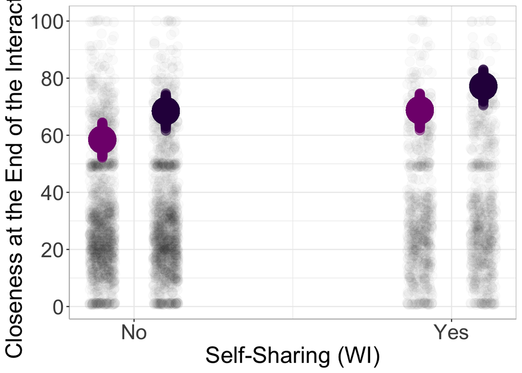

```r
# Extract all posterior distributions
p <- posterior_samples(fit1)[, c(1:3,13)]
colnames(p) <- c("intercept", "b_self_disc", "b_close_deg_out", "b_self_disc_close_deg_out_int")

# Define the number of random draws
n <- 4000

p <- p %>%
  dplyr::mutate(draw = 1:n,
                m_int = median(intercept), # Extract fixed effects medians from the model
                m_b_self_disc = median(b_self_disc),
                m_b_close_deg_out = median(b_close_deg_out),
                m_b_self_disc_close_deg_out_int = median(b_self_disc_close_deg_out_int))

# Create a dataframe that includes predicted y values for each draw for students without a lot of friends
p_lw <- p[rep(seq_len(nrow(p)), each = 2), ] %>%
  dplyr::mutate(seq = rep(c(-.5,.5), n),
                close_deg_out = lw_1.5sd,
                close_deg_out_label = "Low (-1.5 SD)") %>%
  rowwise() %>%
  dplyr::mutate(y_draw = intercept + b_self_disc * seq + b_close_deg_out * close_deg_out +
                  b_self_disc_close_deg_out_int * close_deg_out * seq,
                y_fe = m_int + m_b_self_disc * seq + m_b_close_deg_out * close_deg_out +
                  m_b_self_disc_close_deg_out_int * close_deg_out * seq)

# Create a dataframe that includes predicted y values for each draw for students with a lot of friends
p_up <- p[rep(seq_len(nrow(p)), each = 2), ] %>%
  mutate(seq = rep(c(-.5,.5), n),
         close_deg_out = up_1.5sd,
         close_deg_out_label = "High (+ 1.5 SD)") %>%
  rowwise() %>%
  dplyr::mutate(y_draw = intercept + b_self_disc * seq + b_close_deg_out * close_deg_out +
                  b_self_disc_close_deg_out_int * close_deg_out * seq,
                y_fe = m_int + m_b_self_disc * seq + m_b_close_deg_out * close_deg_out +
                  m_b_self_disc_close_deg_out_int * close_deg_out * seq)

# Merge files
p_all <- rbind(p_lw, p_up)

# Make the grouping variable a factor
p_all$close_deg_out_label <- factor(p_all$close_deg_out_label,
                                    levels = c("Low (-1.5 SD)",
                                               "High (+ 1.5 SD)"))

# Stagger position on the x-axis
p_up$seq2 <- ifelse(p_up$seq == -.5, -0.3,
                    ifelse(p_up$seq == .5, .7, NA))

# Separate the covid_ema dataset in two subsets: one including the data of the people with a lot of friends,
# one including the data of the people without a lot of friends
covid_ema_lw <- covid_ema[covid_ema$baseline_closest_deg_out_norm_c < median(covid_ema$baseline_closest_deg_out_norm_c, na.rm = T),]
covid_ema_lw$SalInt_Disc_Self_2 <- ifelse(covid_ema_lw$SalInt_Disc_Self == 1, .5,
                                              ifelse(covid_ema_lw$SalInt_Disc_Self == 0, -.5, NA))

covid_ema_up <- covid_ema[covid_ema$baseline_closest_deg_out_norm_c < median(covid_ema$baseline_closest_deg_out_norm_c, na.rm = T),]
covid_ema_up$SalInt_Disc_Self_2 <- ifelse(covid_ema_up$SalInt_Disc_Self == 1, .7,
                                              ifelse(covid_ema_up$SalInt_Disc_Self == 0, -.3, NA))

# Plot results -- together
ggplot() +
  geom_jitter(data = covid_ema_lw, aes(x = SalInt_Disc_Self_2,
                                       y = NegativeMood),
              width = .04, alpha = .02, size = 4) +
  geom_jitter(data = covid_ema_up, aes(x = SalInt_Disc_Self_2,
                                       y = NegativeMood),
              width = .04, alpha = .02, size = 4) +
  geom_point(data = p_lw, aes(x = seq, y= y_draw,
                              group = draw),
             color = "#810F7C", alpha = .5, size = 4) +
  geom_point(data = p_lw, aes(x = seq, y = y_fe),
             color = "#810F7C", size = 12) +
  geom_point(data = p_up, aes(x = seq2, y= y_draw,
                              group = draw),
             color = "#2D004B", alpha = .5, size = 4) +
  geom_point(data = p_up, aes(x = seq2,
                              y = y_fe),
             color = "#2D004B", size = 12) +
  labs(y = "Closeness at the End of the Interaction",
       x = "Self-Sharing (WI)") +
  scale_y_continuous(breaks = c(0,20,40,60,80,100)) +
  scale_x_continuous(breaks = c(-.4, .6),
                     labels = c("No", "Yes")) +
  theme_bw() +
  theme(axis.text=element_text(size=20),
        axis.title=element_text(size=22),
        axis.line = element_line(colour = "gray"),
        panel.border = element_rect(colour = "gray"),
        strip.text = element_text(size=16))
```

```r
ggsave(file=sprintf("%s/Figures/3. Closeness_Out-Degree_Self-Disclose.pdf", path),
       units="in", width=8, height=6, dpi=300)
```

##### Model 2: Predictor Variable = Partner-Disclosure

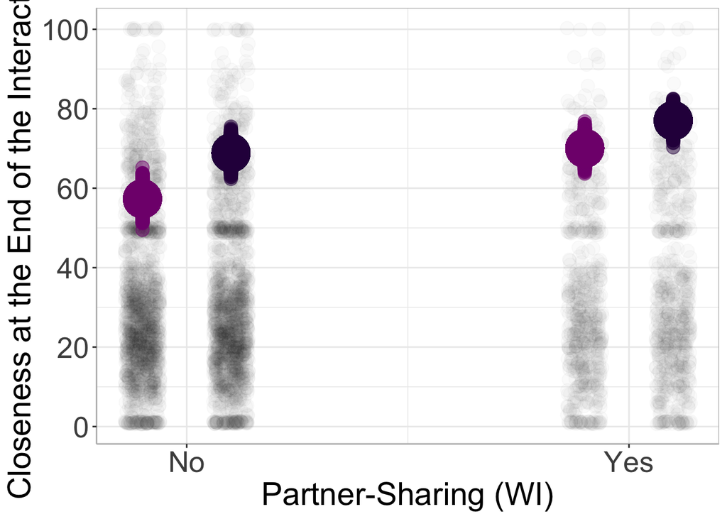

```r
# Extract all posterior distributions
p <- posterior_samples(fit2)[, c(1:3,13)]
colnames(p) <- c("intercept", "b_partner_disc", "b_close_deg_out", "b_partner_disc_close_deg_out_int")

# Define the number of random draws
n <- 4000

p <- p %>%
  dplyr::mutate(draw = 1:n,
                m_int = median(intercept), # Extract fixed effects medians from the model
                m_b_partner_disc = median(b_partner_disc),
                m_b_close_deg_out = median(b_close_deg_out),
                m_b_partner_disc_close_deg_out_int = median(b_partner_disc_close_deg_out_int))

# Calculate  +/-1.5SD
lw_1.5sd <- round(mean(covid_ema$baseline_closest_deg_out_norm_c)-
                    1.5*sd(covid_ema$baseline_closest_deg_out_norm_c),2)
up_1.5sd <- round(mean(covid_ema$baseline_closest_deg_out_norm_c)+
                    1.5*sd(covid_ema$baseline_closest_deg_out_norm_c),2)

# Create a dataframe that includes predicted y values for each draw for students without a lot of friends
p_lw <- p[rep(seq_len(nrow(p)), each = 2), ] %>%
  dplyr::mutate(seq = rep(c(-.5,.5), n),
                close_deg_out = lw_1.5sd,
                close_deg_out_label = "Low (-1.5 SD)") %>%
  rowwise() %>%
  dplyr::mutate(y_draw = intercept + b_partner_disc * seq + b_close_deg_out * close_deg_out +
                  b_partner_disc_close_deg_out_int * close_deg_out * seq,
                y_fe = m_int + m_b_partner_disc * seq + m_b_close_deg_out * close_deg_out +
                  m_b_partner_disc_close_deg_out_int * close_deg_out * seq)

# Create a dataframe that includes predicted y values for each draw for students with a lot of friends
p_up <- p[rep(seq_len(nrow(p)), each = 2), ] %>%
  mutate(seq = rep(c(-.5,.5), n),
         close_deg_out = up_1.5sd,
         close_deg_out_label = "High (+ 1.5 SD)") %>%
  rowwise() %>%
  dplyr::mutate(y_draw = intercept + b_partner_disc * seq + b_close_deg_out * close_deg_out +
                  b_partner_disc_close_deg_out_int * close_deg_out * seq,
                y_fe = m_int + m_b_partner_disc * seq + m_b_close_deg_out * close_deg_out +
                  m_b_partner_disc_close_deg_out_int * close_deg_out * seq)

# Merge files
p_all <- rbind(p_lw, p_up)

# Make the grouping variable a factor
p_all$close_deg_out_label <- factor(p_all$close_deg_out_label,
                                    levels = c("Low (-1.5 SD)",
                                               "High (+ 1.5 SD)"))

# Stagger position on the x-axis
p_up$seq2 <- ifelse(p_up$seq == -.5, -0.3,
                    ifelse(p_up$seq == .5, .7, NA))

# Separate the covid_ema dataset in two subsets: one including the data of the people with a lot of friends,
# one including the data of the people without a lot of friends
covid_ema_lw <- covid_ema[covid_ema$baseline_closest_deg_out_norm_c < median(covid_ema$baseline_closest_deg_out_norm_c, na.rm = T),]
covid_ema_lw$SalInt_Disc_Partner_2 <- ifelse(covid_ema_lw$SalInt_Disc_Partner == 1, .5,
                                          ifelse(covid_ema_lw$SalInt_Disc_Partner == 0, -.5, NA))

covid_ema_up <- covid_ema[covid_ema$baseline_closest_deg_out_norm_c < median(covid_ema$baseline_closest_deg_out_norm_c, na.rm = T),]
covid_ema_up$SalInt_Disc_Partner_2 <- ifelse(covid_ema_up$SalInt_Disc_Partner == 1, .7,
                                          ifelse(covid_ema_up$SalInt_Disc_Partner == 0, -.3, NA))

# Plot results -- together
ggplot() +
  geom_jitter(data = covid_ema_lw, aes(x = SalInt_Disc_Partner_2,
                                       y = NegativeMood),
              width = .04, alpha = .02, size = 4) +
  geom_jitter(data = covid_ema_up, aes(x = SalInt_Disc_Partner_2,
                                       y = NegativeMood),
              width = .04, alpha = .02, size = 4) +
  geom_point(data = p_lw, aes(x = seq, y= y_draw,
                              group = draw),
             color = "#810F7C", alpha = .5, size = 4) +
  geom_point(data = p_lw, aes(x = seq, y = y_fe),
             color = "#810F7C", size = 12) +
  geom_point(data = p_up, aes(x = seq2, y= y_draw,
                              group = draw),
             color = "#2D004B", alpha = .5, size = 4) +
  geom_point(data = p_up, aes(x = seq2,
                              y = y_fe),
             color = "#2D004B", size = 12) +
  labs(y = "Closeness at the End of the Interaction",
       x = "Partner-Sharing (WI)") +
  scale_y_continuous(breaks = c(0,20,40,60,80,100)) +
  scale_x_continuous(breaks = c(-.4, .6),
                     labels = c("No", "Yes")) +
  theme_bw() +
  theme(axis.text=element_text(size=20),
        axis.title=element_text(size=22),
        axis.line = element_line(colour = "gray"),
        panel.border = element_rect(colour = "gray"),
        strip.text = element_text(size=16))
```

```r
ggsave(file=sprintf("%s/Figures/3. Closeness_Out-Degree_Partner-Disclose.pdf", path),
       units="in", width=8, height=6, dpi=300)
```

### Extract Random Intercepts & Slopes

##### Model 1: Predictor Variable = Self-Disclosure

Extract the random effects from the model.

```r
ranef <- ranef(fit1)$`groupID:pID` %>%
  mutate(pID = row.names(.),
                pID = str_remove(pID, "g\\d+c:"),
                pID = str_remove(pID, "g\\d+p:")) %>%
  rename(intercept_ref = `(Intercept)`,
         slope_ref = SalInt_Disc_Self_cw)
```

Extract the fixed effects from the model.

```r
fixef <- data.frame(pID = ranef$pID) %>%
  mutate(intercept_fef = fixef(fit1)[1],
         slope_fef = fixef(fit1)[2])
```

Calculate the final participant-level effects.

```r
ef <- merge(ranef, fixef) %>%
  rowwise() %>%
  mutate(p_intercept = sum(c(intercept_ref, intercept_fef)),
         p_slope = sum(c(slope_ref, slope_fef))) %>%
  select(pID, p_intercept, p_slope) %>%
  arrange(p_slope)
```

Check the mean and standard deviation of the person-level intercepts.

```r
round(mean(ef$p_intercept),2)
```

```
## [1] 68.26
```

```r
round(sd(ef$p_intercept),2)
```

```
## [1] 10.91
```

Check the mean and standard deviation of the person-level slopes.

```r
round(mean(ef$p_slope),2)
```

```
## [1] 9.51
```

```r
round(sd(ef$p_slope),2)
```

```
## [1] 2.1
```

Plot the histogram of the person-level slopes.

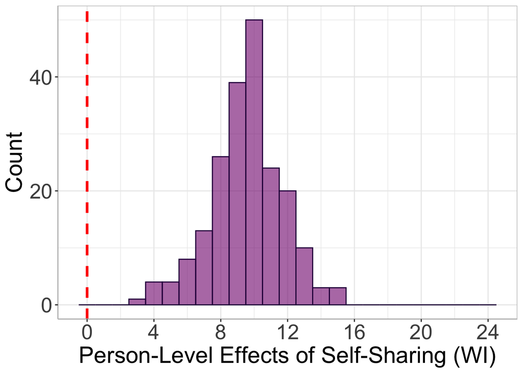

```r
ggplot(ef, aes(p_slope)) +
  geom_histogram(fill = "#810F7C",
                 color = "#2D004B", alpha = .6,
                 binwidth = 1) +
  labs(x = "Person-Level Effects of Self-Sharing (WI)",
       y = "Count") +
  scale_x_continuous(breaks = c(0,4,8,12,16,20,24)) +
  expand_limits(x=c(0, 24)) +
  scale_y_continuous(breaks = c(0,20,40,60)) +
  geom_vline(xintercept = 0, linetype = "dashed",
             color = "red", linewidth = 1.2) +
  theme_bw() +
  theme(axis.text=element_text(size=20),
        axis.title=element_text(size=22),
        axis.line = element_line(colour = "gray"),
        panel.border = element_rect(colour = "gray"),
        strip.text = element_text(size=16))
```

```r
ggsave(file=sprintf("%s/Figures/3. Closeness_Self-Disclose_Person-Level-Effects.pdf", path),
       units="in", width=8, height=6, dpi=300)
```

What percentage of the slopes is higher than zero?

```r
length(which(ef$p_slope>0))/205*100
```

```
## [1] 100
```

##### Model 2: Predictor Variable = Partner-Disclosure

Extract the random effects from the model.

```r
ranef <- ranef(fit2)$`groupID:pID` %>%
  mutate(pID = row.names(.),
                pID = str_remove(pID, "g\\d+c:"),
                pID = str_remove(pID, "g\\d+p:")) %>%
  rename(intercept_ref = `(Intercept)`,
         slope_ref = SalInt_Disc_Partner_cw)
```

Extract the fixed effects from the model.

```r
fixef <- data.frame(pID = ranef$pID) %>%
  mutate(intercept_fef = fixef(fit2)[1],
         slope_fef = fixef(fit2)[2])
```

Calculate the final participant-level effects.

```r
ef <- merge(ranef, fixef) %>%
  rowwise() %>%
  mutate(p_intercept = sum(c(intercept_ref, intercept_fef)),
         p_slope = sum(c(slope_ref, slope_fef))) %>%
  select(pID, p_intercept, p_slope) %>%
  arrange(p_slope)
```

Check the mean and standard deviation of the person-level intercepts.

```r
round(mean(ef$p_intercept),2)
```

```
## [1] 68.29
```

```r
round(sd(ef$p_intercept),2)
```

```
## [1] 10.96
```

Check the mean and standard deviation of the person-level slopes.

```r
round(mean(ef$p_slope),2)
```

```
## [1] 10.44
```

```r
round(sd(ef$p_slope),2)
```

```
## [1] 4.22
```

Plot the histogram of the person-level slopes.

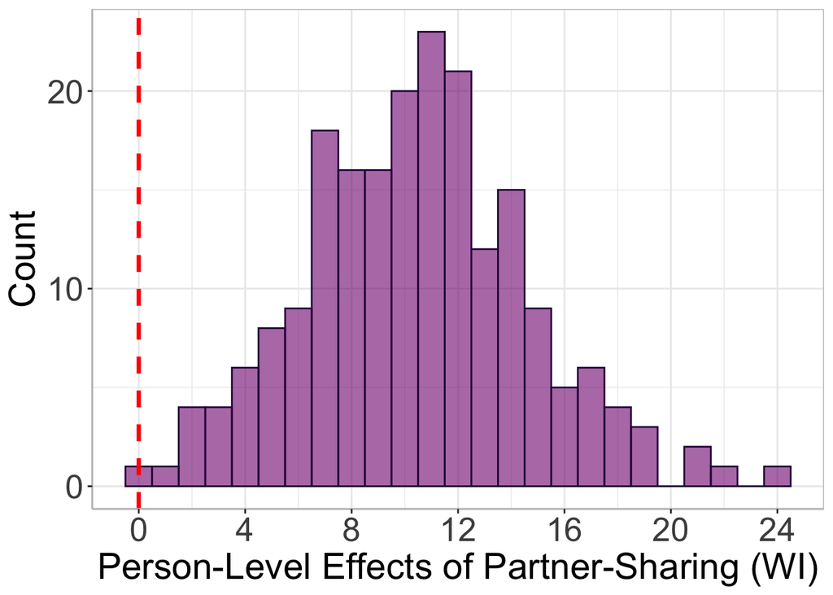

```r
ggplot(ef, aes(p_slope)) +
  geom_histogram(fill = "#810F7C",
                 color = "#2D004B", alpha = .6,
                 binwidth = 1) +
  labs(x = "Person-Level Effects of Partner-Sharing (WI)",
       y = "Count") +
  scale_x_continuous(breaks = c(0,4,8,12,16,20,24)) +
  expand_limits(x=c(0, 24)) +
  scale_y_continuous(breaks = c(0,10,20,40,60)) +
  geom_vline(xintercept = 0, linetype = "dashed",
             color = "red", linewidth = 1.2) +
  theme_bw() +
  theme(axis.text=element_text(size=20),
        axis.title=element_text(size=22),
        axis.line = element_line(colour = "gray"),
        panel.border = element_rect(colour = "gray"),
        strip.text = element_text(size=16))
```

```r
ggsave(file=sprintf("%s/Figures/3. Closeness_Partner-Disclose_Person-Level-Effects.pdf", path),
       units="in", width=8, height=6, dpi=300)
```

What percentage of the slopes is higher than zero?

```r
length(which(ef$p_slope>0))/205*100
```

```
## [1] 100
```